# Island Biogeodiversity:

## Linear Regression for Immigration and Extinction rates

```python
%matplotlib inline
import numpy as np #import numerical and linear algebra libraries
from pandas import read_table #import data frame libraries
from matplotlib import pyplot as plt #import plot libraries


def linregBioG(*args):  #Generic least squares linreg that allows to force intercept at origin

    xs=args[1]
    if len(args)==2: #if only x and y data
        A=np.vstack([xs,xs**0]).transpose() #create matrix A with column space of standard basis
    elif len(args)==3 and args[2]==0: #if extra arg forcing zero intercept
        A=np.vstack([xs,xs*0]).transpose() #create same matrix A but force x**0 column to all zeroes
    else: #don't be tryin nothin funky
            print('invalid entry, program will crash on params call soon!')
            return  #lazy error check here, this return will cause an error in the params call later
    return np.poly1d(np.linalg.lstsq(A,args[0])[0])#lstsq minimizes SSR, then return poly1d
```

Here I read in the data. I use the Pandas library to read the `.csv` file in as a data frame. Because my regression function uses Numpy's linear algebra libraries I need to pass Numpy arrays as arguments, so I use `data_frame.as_matrix()` to convert my data frame columns to Numpy arrays. After reading it in I fit my Parameters using `linregBioG(*args)`.

```python
data=read_table('/home/harris/Documents/R-Data/island.csv',sep=',',header=0,index_col=0) #read in table as data frame
xs=data.R.as_matrix() #store R column as numpy array
iParams=linregBioG(data.I.as_matrix(),xs) #fits params for Immigration
eParams=linregBioG(data.E.as_matrix(),xs,0) #fits params for Extiction, forces zero intercept
```

Here is a plot of the data with the best fit lines for linear relationships between number of species on the island and Extinction, Immigration rates

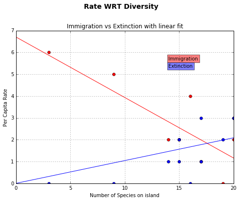

```python
fig=plt.figure() #creates figure object
fig.suptitle('Rate WRT Diversity', fontsize=14, fontweight='bold') #adds title layer


ax = fig.add_subplot(111) #add new subplot to figure
fig.subplots_adjust(top=0.85) #move down for subtitle
ax.set_title('Immigration vs Extinction with linear fit') #add subtitle
ax.set_xlabel('Number of Species on island')#x label
ax.set_ylabel('Per Capita Rate') #y label
ax.text(14.01, 5.652, 'Immigration',
        bbox={'facecolor':'red', 'alpha':0.5, 'pad':2.55}) #add legend box for Immigration
ax.text(14.01, 5.3, 'Extinction',                        #alpha level is for transperency, 1 is opaque, 0 is transparent
        bbox={'facecolor':'blue', 'alpha':0.5, 'pad':2.55}) #add legend box for extinction
ax.plot(xs,np.asarray(data.I.as_matrix()),'ro') #add data points for immigration ('ro' for red dots)
ax.plot(xs,np.asarray(data.E.as_matrix()),'bo') #add data points for extinction
xss=np.linspace(0,max(data.R),len(data.R)) #creates x vector for lines
ax.plot(xss,iParams(xss),'r') #add best fit line for Immigration('r' for red)
ax.plot(xss,eParams(xss),'b') #add best fit line for Extinction
ax.grid()
fig.set_size_inches(8,6) #set figure size in inches


plt.show() #display figure
```

Next, we extract $I_x$ as the intercept of our linear fit for $I$, or,in this case, `iParams[0]`:

```python
ix=iParams[0]
a1=iParams[1]
print([ix,a1])
```

```
[6.7056107954545414, -0.27734374999999983]
```

An Intercept of `6.7056` seems to correspond with the graph above, for future use, I have named it `ix` . The other coefficient, stored in `iParams[1]`, is the slope of our linear relationship, I have named it $a_1$. We'll use this to extract $P$ using the equation:

$$ a_1 = -\frac{I_x}{P} \Rightarrow P = -\frac{I_x}{a_1} $$

```python
p=-ix/a1
p
```

```
24.177976952624839
```

We can use this to solve for $E_X$ using our coefficient for the linear fit for $E$, stored in `eParams[1]`, which I will name $a_2$, along with the equation:

$$ a_2 = \frac{E_x}{P} \Rightarrow E_x = {a_2}\cdot{P} $$

```python
a2=eParams[1]
ex=a2*p
ex
```

```
2.5231502861582134
```

```python
r=np.empty(shape=[11])
r[0]=3
for i in range(1,11):
    r[i]=r[i-1]+iParams(r[i-1])-eParams(r[i-1])
```

```python
r
```

```
array([  3.        ,   8.56050741,  11.99856287,  14.12430868,
        15.43865492,  16.25131371,  16.75377973,  17.0644539 ,
        17.25654339,  17.3753121 ,  17.44874666])
```

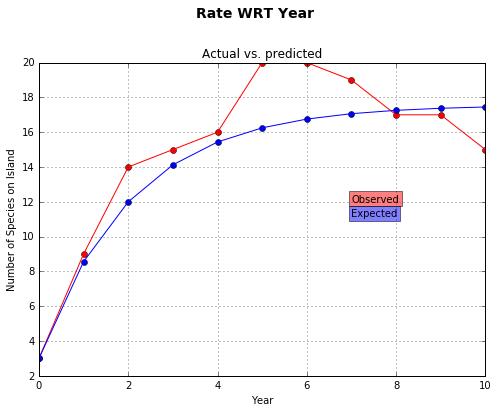

```python
fig1=plt.figure() #creates figure object
fig1.suptitle('Rate WRT Year', fontsize=14, fontweight='bold') #adds title layer


ax1 = fig1.add_subplot(111) #add new subplot to figure
fig1.subplots_adjust(top=0.85) #move down for subtitle
ax1.set_title('Actual vs. predicted') #add subtitle
ax1.set_xlabel('Year')#x label
ax1.set_ylabel('Number of Species on Island') #y label
ax1.text(7, 12, 'Observed',
        bbox={'facecolor':'red', 'alpha':0.5, 'pad':2.55}) #add legend box for observed
ax1.text(7, 11.15, 'Expected',                        #alpha level is for transperency, 1 is opaque, 0 is transparent
        bbox={'facecolor':'blue', 'alpha':0.5, 'pad':2.55}) #add legend box for expected
xxs=np.asarray(data.index) #creates x vector for lines
ax1.plot(xxs,data.R.as_matrix(),'ro') #add data points for immigration ('ro' for red dots)
ax1.plot(xxs,r,'bo') #add data points for extinction
ax1.plot(xxs,data.R.as_matrix(),'r') #add best fit line for Immigration('r' for red)
ax1.plot(xxs,r,'b') #add best fit line for Extinction
ax1.grid()
fig1.set_size_inches(8,6) #set figure size in inches


plt.show() #display figure
```

Solving $R_{t+1}=R_t$ is the same as solving $I_t=E_t$ after substituting $R_t$ for $R_{t+1}$ and subtracting $R_t$ from both sides, which leaves us to solve:

$$ I_x + a_1 R_e = a_2R_e \Rightarrow R_e = \frac{I_x}{a_2-a_1} $$

```python
re=ix/(a2-a1)
re
```

```
17.567699697936035
```

This result seems to agree with our model, which seems to be approaching somewhere near 17.5, both in our `for` loop and on the graph.

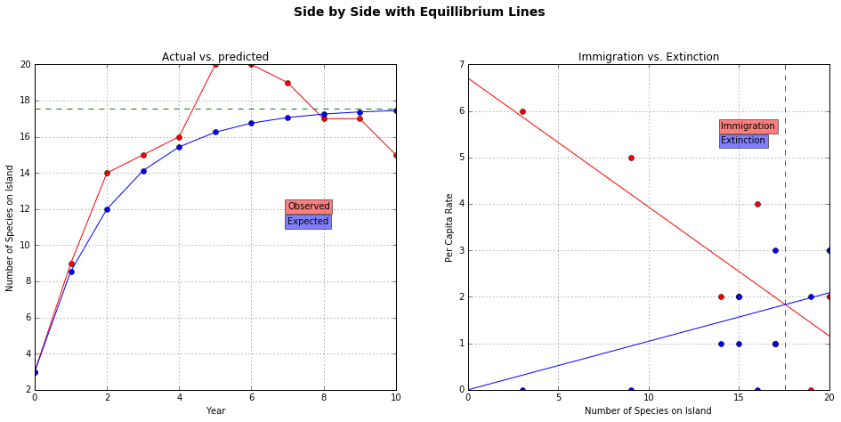

```python
fig2=plt.figure() #creates figure object
fig2.suptitle('Side by Side with Equillibrium Lines', fontsize=14, fontweight='bold') #adds title layer


ax2 = fig2.add_subplot(121) #add new subplot to figure
fig2.subplots_adjust(top=0.85) #move down for subtitle
ax2.set_title('Actual vs. predicted') #add subtitle
ax2.set_xlabel('Year')#x label
ax2.set_ylabel('Number of Species on Island') #y label
ax2.text(7, 11.99, 'Observed',
        bbox={'facecolor':'red', 'alpha':0.5, 'pad':2.55}) #add legend box for observed values
ax2.text(7, 11.15, 'Expected',                          #alpha level is for transperency, 1 is opaque, 0 is transparent
        bbox={'facecolor':'blue', 'alpha':0.5, 'pad':2.55}) #add legend box for expected
xxs=np.asarray(data.index) #creates x vector for lines
ax2.plot(xxs,data.R.as_matrix(),'ro') #add data points for immigration ('ro' for red dots)
ax2.plot(xxs,r,'bo') #add data points for extinction
ax2.plot(xxs,data.R.as_matrix(),'r') #add best fit line for Immigration('r' for red)
ax2.plot(xxs,r,'b') #add best fit line for Extinction
ax2.axhline(y=re,color='g',linestyle='--')
ax2.grid()

ax3 = fig2.add_subplot(122) #add new subplot to figure
ax3.set_title('Immigration vs. Extinction') #add subtitle
ax3.set_xlabel('Number of Species on Island')#x label
ax3.set_ylabel('Per Capita Rate') #y label
ax3.text(14.01, 5.61, 'Immigration',
        bbox={'facecolor':'red', 'alpha':0.5, 'pad':2.55}) #add legend box for Immigration
ax3.text(14.01, 5.3, 'Extinction',                        #alpha level is for transperency, 1 is opaque, 0 is transparent
        bbox={'facecolor':'blue', 'alpha':0.5, 'pad':2.55}) #add legend box for extinction
ax3.plot(xs,np.asarray(data.I.as_matrix()),'ro') #add data points for immigration ('ro' for red dots)
ax3.plot(xs,np.asarray(data.E.as_matrix()),'bo') #add data points for extinction
ax3.plot(xss,iParams(xss),'r') #add best fit line for Immigration('r' for red)
ax3.plot(xss,eParams(xss),'b') #add best fit line for Extinction
ax3.axvline(x=re,color='g',linestyle='--')
ax3.grid()

fig2.set_size_inches(16,7) #set figure size in inches



plt.show() #display figure
```